# Oral de stage

Marc XU

04/06/2019

# Neural network

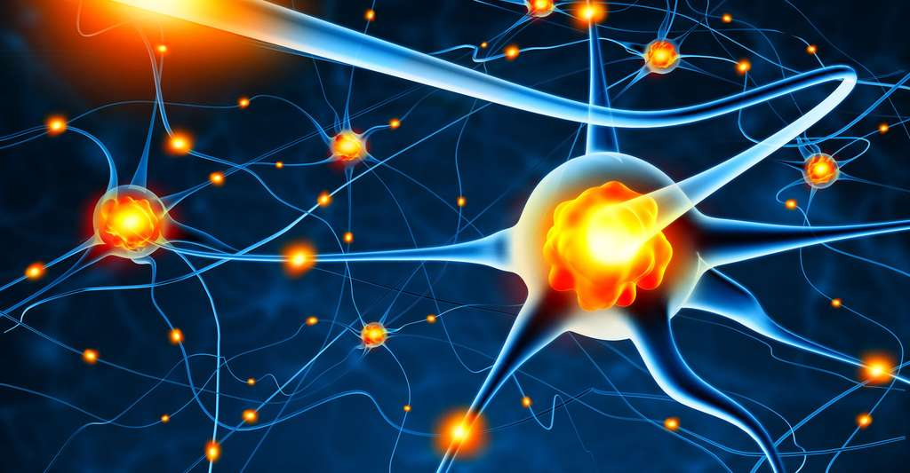

## Déroulement du stage

- Apprentissage de R avancé
- Apprentissage de la méthode de prédiction choisie et de sa librairie

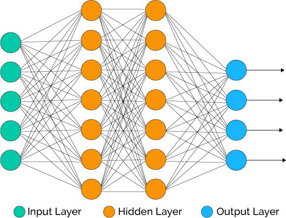

- Apprentissage des critères de validation d’un modèle d’apprentissage en classification
- Application aux données “membranes placentaires”

## Objectif du stage

Problématique :

**Établir un modèle permettant de prédire si une molécule donnée traverse la membrane placentaire.**

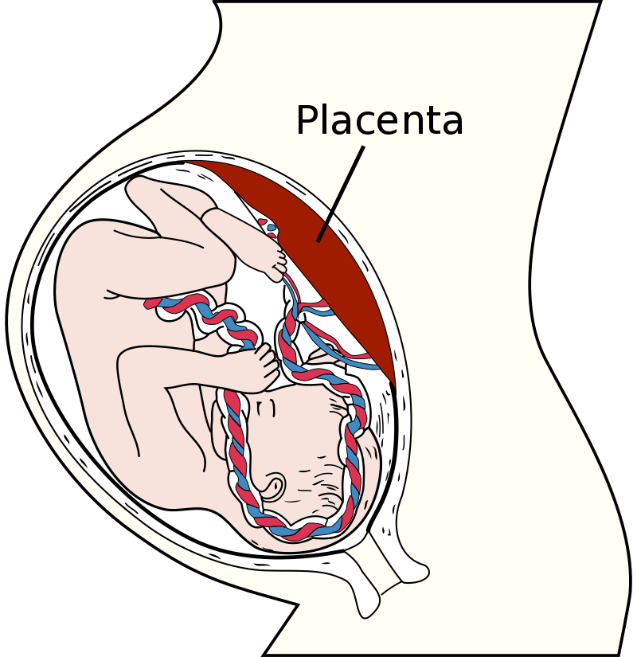

- Méthode utilisée : utilisation d’un réseau de neurone

# Les données

## Jeu de données

Le jeu de données comporte :

- 90 molécules décrites par
- 207 descripteurs calculées avec le logiciel e-dragon
- une mesure de clairance, CI

| Noms | CI | a_don | a_ICM | BCUT_SLOGP_1 |
| --- | --- | --- | --- | --- |
| Abacavir | 0.47 | 3 | 1.596392 | -0.6109613 |
| Acipimox | 0.25 | 0 | 1.882856 | -0.5409169 |
| Acyclovir | 0.17 | 3 | 1.850507 | -0.4247874 |
| Alanine_L | 0.30 | 0 | 1.669180 | -0.4068410 |
| Alfentanil | 0.75 | 0 | 1.549211 | -0.4323930 |
| Aminohippuric_acid_PAH | 0.47 | 2 | 1.749060 | -0.5425675 |

## Nettoyage des données

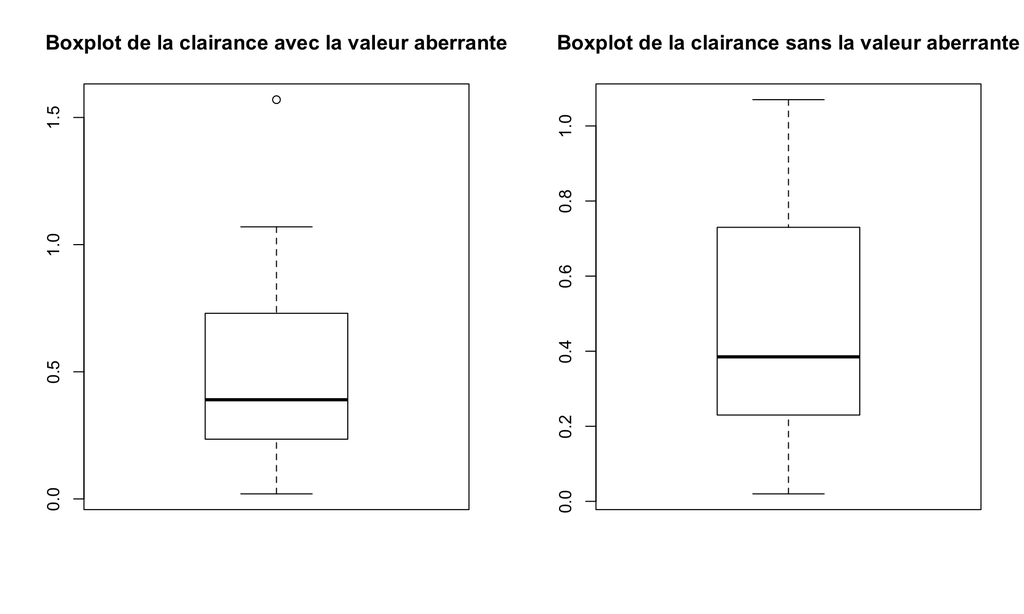

## Transformation de la variable “clairance” (CI)

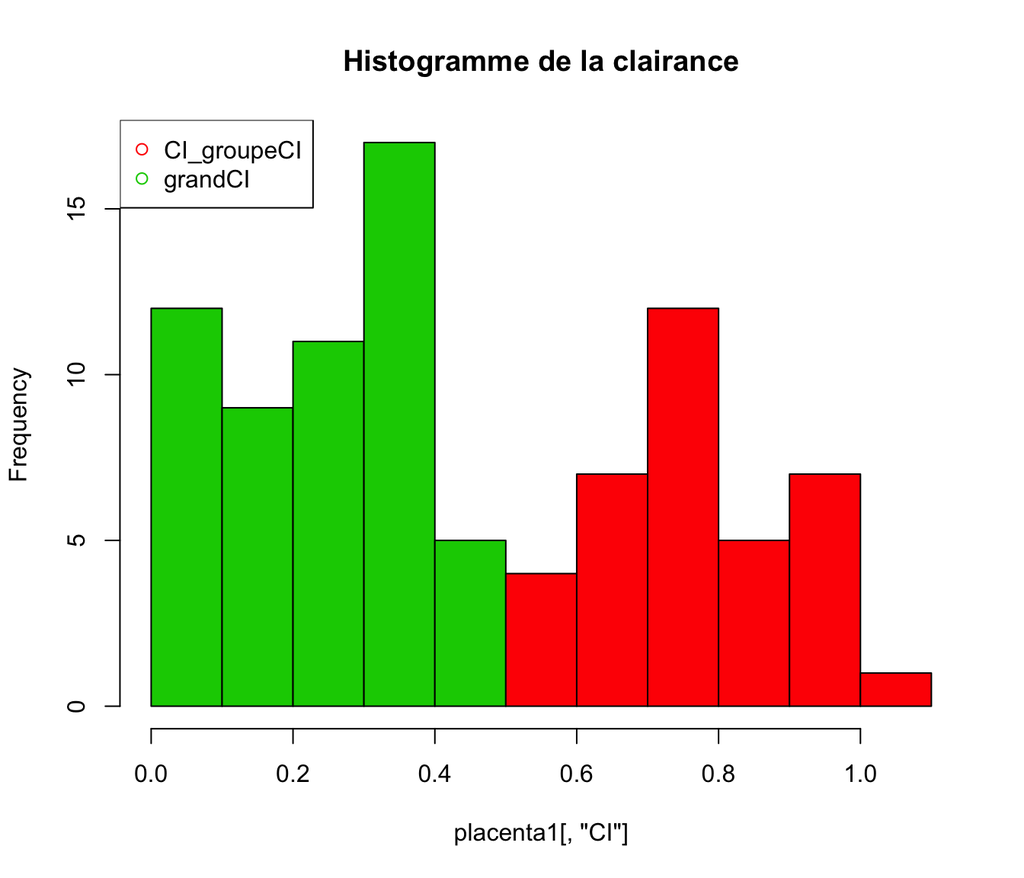

## Visualisation des données

Données non normalisés

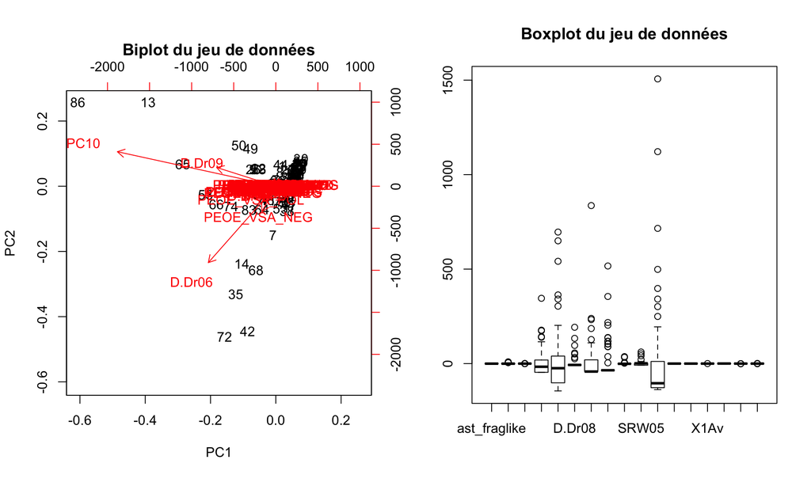

Source : https://journals.openedition.org/cal/7364

Données après normalisés

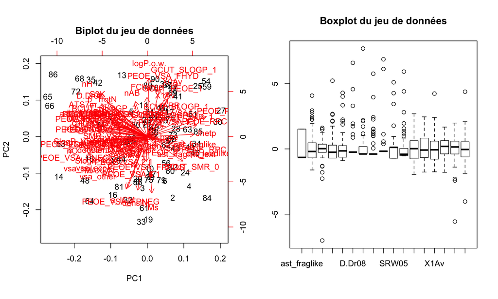